# Mediation and pQTL Workshop: Short Course on Systems Genetics 2015

10/3/2015

## Introduction

We will explore RNA and protein expression data from [Diversity Outbred (DO) Mice](http://jaxmice.jax.org/strain/009376.html). 192 DO mice (98 females & 94 males) were placed on either a chow diet or a high fat diet. They were aged to approximately 22 weeks and a variety of physiological phenotypes were measured. At sacrifice, we collected liver tissue and measured gene expression using RNASeq and protein levels using mass spectrometry.

| Sex | chow | HFD |
| --- | --- | --- |
| F | 50 | 48 |
| M | 48 | 46 |

## Libraries and Data Import

We will load [ggplot2](http://ggplot2.org/), a R library for producing layered graphics.

```r
library(ggplot2)
```

Load in the RNA and protein expression data.

```r
load("/data/Rdata/DO192_DataforSysGenCourse.Rdata")
```

View the contents of the data set using ls(). You can also use the Environment tab in RStudio to view data.

```r
ls()
```

```
##  [1] "annotations.protein.192" "annotations.rna.192"
##  [3] "covariates.protein.192"  "covariates.rna.192"
##  [5] "expr.protein.192"        "expr.rna.192"
##  [7] "K.LOCO.192"              "notYM"
##  [9] "probs.192"               "samples.192"
## [11] "snps.64K"
```

## RNA Expression Data

View some of the properties of the RNA expression data. It is a large matrix with 192 rows and 25050 columns. Samples are in rows and Ensembl gene IDs are in columns.

```r
class(expr.rna.192)
```

```
## [1] "matrix"
```

```r
dim(expr.rna.192)
```

```
## [1]   192 25050
```

Let’s have a look at sample names and at the first 20 Ensembl gene IDs.

```r
rownames(expr.rna.192)
```

```
##   [1] "F326" "F327" "F328" "F329" "F330" "F331" "F332" "F333" "F334" "F335"
##  [11] "F336" "F337" "F338" "F339" "F340" "F341" "F342" "F343" "F344" "F345"
##  [21] "F346" "F347" "F348" "F349" "F350" "F351" "F352" "F353" "F354" "F355"
##  [31] "F356" "F357" "F358" "F359" "F360" "F361" "F362" "F363" "F364" "F365"
##  [41] "F366" "F367" "F368" "F369" "F371" "F372" "F373" "F374" "F375" "F376"
##  [51] "F377" "F378" "F379" "F380" "F381" "F382" "F383" "F384" "F385" "F386"
##  [61] "F387" "F388" "F389" "F390" "F391" "F392" "F393" "F394" "F395" "F396"
##  [71] "F397" "F398" "F399" "F400" "F401" "F402" "F403" "F405" "F406" "F407"
##  [81] "F408" "F409" "F410" "F411" "F412" "F413" "F414" "F415" "F416" "F417"
##  [91] "F418" "F419" "F420" "F421" "F422" "F423" "F424" "F425" "M326" "M327"
## [101] "M328" "M329" "M330" "M331" "M332" "M333" "M334" "M335" "M336" "M337"
## [111] "M339" "M340" "M341" "M342" "M343" "M344" "M345" "M347" "M348" "M349"
## [121] "M350" "M351" "M352" "M353" "M354" "M355" "M356" "M357" "M358" "M359"
## [131] "M360" "M361" "M362" "M363" "M364" "M365" "M366" "M367" "M368" "M369"
## [141] "M370" "M371" "M372" "M373" "M374" "M375" "M376" "M377" "M378" "M379"
## [151] "M380" "M381" "M382" "M383" "M384" "M385" "M386" "M387" "M388" "M389"
## [161] "M390" "M391" "M392" "M393" "M394" "M395" "M396" "M397" "M398" "M399"
## [171] "M400" "M402" "M403" "M404" "M405" "M406" "M407" "M408" "M409" "M410"
## [181] "M411" "M415" "M416" "M417" "M418" "M419" "M420" "M421" "M422" "M423"
## [191] "M424" "M425"
```

```r
colnames(expr.rna.192)[1:20]
```

```
##  [1] "ENSMUSG00000000001" "ENSMUSG00000000028" "ENSMUSG00000000031"
##  [4] "ENSMUSG00000000037" "ENSMUSG00000000049" "ENSMUSG00000000056"
##  [7] "ENSMUSG00000000058" "ENSMUSG00000000078" "ENSMUSG00000000085"
## [10] "ENSMUSG00000000088" "ENSMUSG00000000093" "ENSMUSG00000000094"
## [13] "ENSMUSG00000000120" "ENSMUSG00000000126" "ENSMUSG00000000127"
## [16] "ENSMUSG00000000131" "ENSMUSG00000000134" "ENSMUSG00000000142"
## [19] "ENSMUSG00000000148" "ENSMUSG00000000149"
```

Early in the course we looked at methods for dealing with missing data. How much is missing in the RNA expression data?

```r
apply(is.na(expr.rna.192), 1, sum)
```

```
## F326 F327 F328 F329 F330 F331 F332 F333 F334 F335 F336 F337 F338 F339 F340
##    0    0    0    0    0    0    0    0    0    0    0    0    0    0    0
## F341 F342 F343 F344 F345 F346 F347 F348 F349 F350 F351 F352 F353 F354 F355
##    0    0    0    0    0    0    0    0    0    0    0    0    0    0    0
## F356 F357 F358 F359 F360 F361 F362 F363 F364 F365 F366 F367 F368 F369 F371
##    0    0    0    0    0    0    0    0    0    0    0    0    0    0    0
## F372 F373 F374 F375 F376 F377 F378 F379 F380 F381 F382 F383 F384 F385 F386
##    0    0    0    0    0    0    0    0    0    0    0    0    0    0    0
## F387 F388 F389 F390 F391 F392 F393 F394 F395 F396 F397 F398 F399 F400 F401
##    0    0    0    0    0    0    0    0    0    0    0    0    0    0    0
## F402 F403 F405 F406 F407 F408 F409 F410 F411 F412 F413 F414 F415 F416 F417
##    0    0    0    0    0    0    0    0    0    0    0    0    0    0    0
## F418 F419 F420 F421 F422 F423 F424 F425 M326 M327 M328 M329 M330 M331 M332
##    0    0    0    0    0    0    0    0    0    0    0    0    0    0    0
## M333 M334 M335 M336 M337 M339 M340 M341 M342 M343 M344 M345 M347 M348 M349
##    0    0    0    0    0    0    0    0    0    0    0    0    0    0    0
## M350 M351 M352 M353 M354 M355 M356 M357 M358 M359 M360 M361 M362 M363 M364
##    0    0    0    0    0    0    0    0    0    0    0    0    0    0    0
## M365 M366 M367 M368 M369 M370 M371 M372 M373 M374 M375 M376 M377 M378 M379
##    0    0    0    0    0    0    0    0    0    0    0    0    0    0    0
## M380 M381 M382 M383 M384 M385 M386 M387 M388 M389 M390 M391 M392 M393 M394
##    0    0    0    0    0    0    0    0    0    0    0    0    0    0    0
## M395 M396 M397 M398 M399 M400 M402 M403 M404 M405 M406 M407 M408 M409 M410
##    0    0    0    0    0    0    0    0    0    0    0    0    0    0    0
## M411 M415 M416 M417 M418 M419 M420 M421 M422 M423 M424 M425
##    0    0    0    0    0    0    0    0    0    0    0    0
```

None of the samples are missing RNA expression data.

Covariates of the 192 samples include sex, diet, sex-by-diet interaction, batch, generation, and coat color.

```r
dim(covariates.rna.192)
```

```
## [1] 192   6
```

Let’s look at the first several rows of covariates.

```r
head(covariates.rna.192)
```

```
##      Sex Diet Sdinteraction Batch   Gen Coat.Color
## F326   F chow             1     2 G11L1      black
## F327   F chow             1     2 G11L1      black
## F328   F chow             1     2 G11L1      white
## F329   F chow             1     2 G11L1     agouti
## F330   F chow             1     2 G11L1     agouti
## F331   F chow             1     2 G11L1      black
```

View sex-by-diet interaction groups (females on chow or high fat diet, males on chow or high fat). The group sizes should be similar.

```r
with(covariates.rna.192,  table(factor(Sdinteraction, labels=c("FC", "FH", "MC", "MH"))))
```

```
##
## FC FH MC MH
## 50 48 48 46
```

Look at the coat color frequencies.

```r
table(covariates.rna.192$Coat.Color)
```

```
##
##       agouti agouti blaze        black         buff          red
##          131            2           30            3            1
##        white
##           25
```

Thirteen percent of the animals are white, and sixteen percent are black.

Annotations describe genomic location, symbol, strand, and more for genes.

```r
dim(annotations.rna.192)
```

```
## [1] 25050     9
```

Let’s have a look at the column names in the annotation data, and the number of annotations for each chromosome.

```r
names(annotations.rna.192)
```

```
## [1] "EnsemblID"     "Gene"          "Chr"           "Start.Mbp"
## [5] "End.Mbp"       "Gene.Biotype"  "Strand"        "Mean.per.Expr"
## [9] "Nonzeros"
```

```r
table(annotations.rna.192$Chr)
```

```
##
##    1   10   11   12   13   14   15   16   17   18   19    2    3    4    5
## 1432 1106 2084  924  934  886  877  731 1180  583  735 2163 1161 1843 1475
##    6    7    8    9    X
## 1405 1879 1261 1280 1111
```

Notice that chromosomes are character variables. Convert the chromosome numbers to numeric, including the X chromosome. Once converted to numeric, the chromosome numbers will order correctly.

```r
class(annotations.rna.192$Chr)
```

```
## [1] "character"
```

```r
annotations.rna.192 <- transform(annotations.rna.192, Chr.num =  as.numeric(ifelse(Chr=="X", "20", Chr)))
class(annotations.rna.192$Chr.num)
```

```
## [1] "numeric"
```

```r
table(annotations.rna.192$Chr.num)
```

```
##
##    1    2    3    4    5    6    7    8    9   10   11   12   13   14   15
## 1432 2163 1161 1843 1475 1405 1879 1261 1280 1106 2084  924  934  886  877
##   16   17   18   19   20
##  731 1180  583  735 1111
```

How many RNA traits are mapped to the Y chromosome or mitochondrial genome?

```r
length(notYM)
```

```
## [1] 25112
```

```r
sum(1-notYM)
```

```
## [1] 62
```

62 RNA traits map to the Y chromosome or mitochondrial genome.

## Protein Expression Data

The protein expression data are in a large matrix of 192 rows and 8050 columns.

```r
class(expr.protein.192)
```

```
## [1] "matrix"
```

```r
dim(expr.protein.192)
```

```
## [1]  192 8050
```

Let’s look at the sample IDs and at the first 20 Ensembl protein IDs.

```r
rownames(expr.protein.192)
```

```
##   [1] "F326" "F327" "F328" "F329" "F330" "F331" "F332" "F333" "F334" "F335"
##  [11] "F336" "F337" "F338" "F339" "F340" "F341" "F342" "F343" "F344" "F345"
##  [21] "F346" "F347" "F348" "F349" "F350" "F351" "F352" "F353" "F354" "F355"
##  [31] "F356" "F357" "F358" "F359" "F360" "F361" "F362" "F363" "F364" "F365"
##  [41] "F366" "F367" "F368" "F369" "F371" "F372" "F373" "F374" "F375" "F376"
##  [51] "F377" "F378" "F379" "F380" "F381" "F382" "F383" "F384" "F385" "F386"
##  [61] "F387" "F388" "F389" "F390" "F391" "F392" "F393" "F394" "F395" "F396"
##  [71] "F397" "F398" "F399" "F400" "F401" "F402" "F403" "F405" "F406" "F407"
##  [81] "F408" "F409" "F410" "F411" "F412" "F413" "F414" "F415" "F416" "F417"
##  [91] "F418" "F419" "F420" "F421" "F422" "F423" "F424" "F425" "M326" "M327"
## [101] "M328" "M329" "M330" "M331" "M332" "M333" "M334" "M335" "M336" "M337"
## [111] "M339" "M340" "M341" "M342" "M343" "M344" "M345" "M347" "M348" "M349"
## [121] "M350" "M351" "M352" "M353" "M354" "M355" "M356" "M357" "M358" "M359"
## [131] "M360" "M361" "M362" "M363" "M364" "M365" "M366" "M367" "M368" "M369"
## [141] "M370" "M371" "M372" "M373" "M374" "M375" "M376" "M377" "M378" "M379"
## [151] "M380" "M381" "M382" "M383" "M384" "M385" "M386" "M387" "M388" "M389"
## [161] "M390" "M391" "M392" "M393" "M394" "M395" "M396" "M397" "M398" "M399"
## [171] "M400" "M402" "M403" "M404" "M405" "M406" "M407" "M408" "M409" "M410"
## [181] "M411" "M415" "M416" "M417" "M418" "M419" "M420" "M421" "M422" "M423"
## [191] "M424" "M425"
```

```r
colnames(expr.protein.192)[1:20]
```

```
##  [1] "ENSMUSP00000115512" "ENSMUSP00000027036" "ENSMUSP00000129157"
##  [4] "ENSMUSP00000132612" "ENSMUSP00000040756" "ENSMUSP00000125348"
##  [7] "ENSMUSP00000059261" "ENSMUSP00000071955" "ENSMUSP00000116627"
## [10] "ENSMUSP00000051248" "ENSMUSP00000095437" "ENSMUSP00000027050"
## [13] "ENSMUSP00000085986" "ENSMUSP00000027056" "ENSMUSP00000080413"
## [16] "ENSMUSP00000027068" "ENSMUSP00000027071" "ENSMUSP00000085900"
## [19] "ENSMUSP00000027057" "ENSMUSP00000071616"
```

How much is missing in the protein expression data?

```r
apply(is.na(expr.protein.192),1,sum)
```

```
## F326 F327 F328 F329 F330 F331 F332 F333 F334 F335 F336 F337 F338 F339 F340
## 1638  931 1358 1389 1432 1180 1512 1103 1510 1351 1666  930 1388 1807 1544
## F341 F342 F343 F344 F345 F346 F347 F348 F349 F350 F351 F352 F353 F354 F355
## 1293 1387 1638 1431 1387 1666 1388 1567 1184 1360 1510 1433 1183  839 1510
## F356 F357 F358 F359 F360 F361 F362 F363 F364 F365 F366 F367 F368 F369 F371
## 1510 1180 1566  933 1351 1543 1543 1565 1360 1809  837 1292 1639 1810  837
## F372 F373 F374 F375 F376 F377 F378 F379 F380 F381 F382 F383 F384 F385 F386
## 1808 1180 1688 1360  929 1809 1251 1184 1666  836 1294 1103 1435 1678 1184
## F387 F388 F389 F390 F391 F392 F393 F394 F395 F396 F397 F398 F399 F400 F401
## 1512 1293 1102 1659 1543 1564 1359 1250 1319 1658 1319 1659 1389 1684  838
## F402 F403 F405 F406 F407 F408 F409 F410 F411 F412 F413 F414 F415 F416 F417
##  931  838 1360 1180 1320 1250 1641  836 1684 1182 1106 1640 1666 1543 1385
## F418 F419 F420 F421 F422 F423 F424 F425 M326 M327 M328 M329 M330 M331 M332
## 1807  929 1320 1352 1689  837 1666 1431 1388 1292 1667 1811 1321 1183 1658
## M333 M334 M335 M336 M337 M339 M340 M341 M342 M343 M344 M345 M347 M348 M349
## 1510 1319 1807 1102 1386 1564 1251 1639 1659 1319 1102 1565 1395 1183 1183
## M350 M351 M352 M353 M354 M355 M356 M357 M358 M359 M360 M361 M362 M363 M364
## 1250 1389 1322 1364 1351 1180  934 1388 1510 1684 1353 1102 1390 1511 1660
## M365 M366 M367 M368 M369 M370 M371 M372 M373 M374 M375 M376 M377 M378 M379
## 1292 1183  931 1353 1252 1658 1183 1251 1389 1251 1388 1666 1388 1351 1184
## M380 M381 M382 M383 M384 M385 M386 M387 M388 M389 M390 M391 M392 M393 M394
## 1543 1544 1639 1391 1660 1666 1320 1666 1433 1293 1431 1639 1667 1183  930
## M395 M396 M397 M398 M399 M400 M402 M403 M404 M405 M406 M407 M408 M409 M410
## 1351 1387 1564  930 1362 1251 1352 1392 1102 1564 1181 1102 1543 1292  837
## M411 M415 M416 M417 M418 M419 M420 M421 M422 M423 M424 M425
## 1295 1102 1432 1250 1565 1180 1639 1543 1807 1320 1359 1353
```

All samples are missing data for a considerable proportion of the 8050 proteins. What is the range of missing data across proteins?

```
## stat_bin: binwidth defaulted to range/30. Use 'binwidth = x' to adjust this.
```

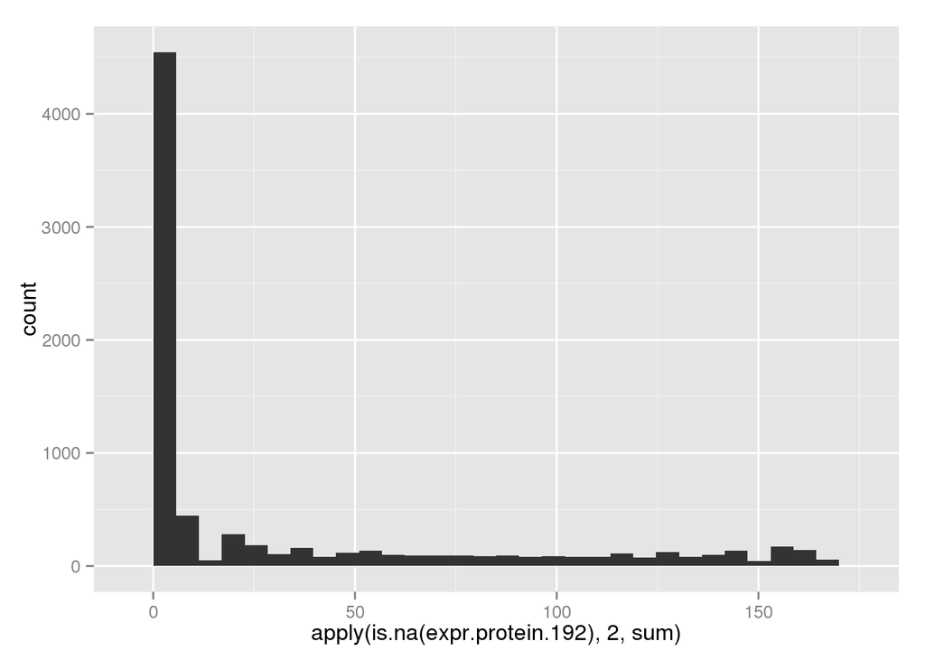

```r
qplot(apply(is.na(expr.protein.192), 2, sum))
```

Some of the proteins have a lot of missing data. Keep this in mind.

What is the proportion of proteins that have no missing data?

```r
sum((apply(is.na(expr.protein.192),2,sum))==0)/8050
```

```
## [1] 0.5572671
```

As with the RNA expression data, covariates describe the characteristics of 192 samples of protein expression data. Every sample has a unique combination of tag and batch.

```r
dim(covariates.protein.192)
```

```
## [1] 192  12
```

```r
head(covariates.protein.192)
```

```
##      Sex Diet Sdinteraction Tag Batch   Protein.Quant.Label Cap.No.
## F326   F chow             1   9     2 S01~rq_130a_sn_scaled      18
## F327   F chow             1   9     6 S05~rq_130a_sn_scaled      54
## F328   F chow             1   8     5 S04~rq_129b_sn_scaled      44
## F329   F chow             1   3     3 S02~rq_127a_sn_scaled      21
## F330   F chow             1   5     9 S08~rq_128a_sn_scaled      77
## F331   F chow             1   4    10 S09~rq_127b_sn_scaled      85
##      Mouse.No. Concatenated.Code TMT.Set TMT.label Index
## F326       326              18FS      S1      130a    18
## F327       327              54FS      S5      130a    58
## F328       328              44FS      S4      129b    47
## F329       329              21FS      S2      127a    22
## F330       330              77FS      S8      128a    84
## F331       331              85FS      S9      127b    93
```

Let’s check group sizes for sex-by-diet interaction, and for combinations of tag and batch.

```r
table(covariates.protein.192$Sdinteraction)
```

```
##
##  1  2  3  4
## 50 48 48 46
```

```r
with(covariates.protein.192, table(Tag, Batch))
```

```
##     Batch
## Tag  1 2 3 4 5 6 7 8 9 10 11 12 13 14 15 16 17 18 19 20 21
##   1  1 1 1 1 1 1 1 1 1  1  1  1  1  1  1  1  1  1  1  1  0
##   2  1 0 0 0 0 1 0 0 0  0  0  0  1  1  1  1  1  1  1  1  1
##   3  1 0 1 1 1 1 1 1 1  1  1  1  1  1  1  1  1  1  1  1  0
##   4  1 1 1 1 1 1 1 1 1  1  1  1  1  1  1  1  1  1  1  1  1
##   5  0 1 1 1 1 1 1 1 1  1  1  1  1  1  1  1  1  1  1  1  1
##   6  1 1 1 1 1 1 1 1 1  1  1  1  1  1  0  1  1  1  1  1  1
##   7  1 1 1 1 1 1 1 1 1  1  1  1  1  1  1  1  1  1  1  1  0
##   8  1 1 1 1 1 1 1 1 1  1  1  1  1  1  1  1  1  1  1  1  0
##   9  1 1 1 1 1 1 1 1 0  1  1  1  1  1  1  1  1  1  1  1  1
##   10 1 1 1 1 1 1 1 1 1  1  1  1  1  1  1  1  1  1  1  1  1
```

As with RNA expression data, annotations describe the proteins.

```r
dim(annotations.protein.192)
```

```
## [1] 8050   11
```

```r
names(annotations.protein.192)
```

```
##  [1] "Ensembl.Protein.ID"    "Ensembl.Gene.ID"
##  [3] "Ensembl.Transcript.ID" "Associated.Gene.Name"
##  [5] "Chromosome.Name"       "Gene.Start..bp."
##  [7] "Gene.End..bp."         "Transcript.Start..bp."
##  [9] "Gene.Biotype"          "Transcript.Biotype"
## [11] "Description"
```

```r
table(annotations.protein.192$Chromosome.Name)
```

```
##
##   1  10  11  12  13  14  15  16  17  18  19   2   3   4   5   6   7   8
## 492 414 668 301 278 285 320 256 372 203 319 624 412 487 516 419 576 446
##   9   X
## 439 223
```

```r
class(annotations.protein.192$Chromosome.Name)
```

```
## [1] "character"
```

Chromosome.Name is stored as a character variable. It is convenient to convert it to a numeric variable. Once it’s converted, check the number of annotations per chromosome.

```r
annotations.protein.192 <-
  transform(annotations.protein.192, Chr.num =
              as.numeric(ifelse(Chromosome.Name=="X", "20",
                                Chromosome.Name)))
class(annotations.protein.192$Chr.num)
```

```
## [1] "numeric"
```

```r
table(annotations.protein.192$Chr.num)
```

```
##
##   1   2   3   4   5   6   7   8   9  10  11  12  13  14  15  16  17  18
## 492 624 412 487 516 419 576 446 439 414 668 301 278 285 320 256 372 203
##  19  20
## 319 223
```

## Haplotype probabilities, SNPs, and kinship

Recall that haplotype probabilities are stored in a 3D array.

```r
dim(probs.192)
```

```
## [1]   192     8 64000
```

View the physical and genetic positions of the “pseudo-SNP” grid equally spaced on the genetic map. Note as before that Chr is a character variable.

```r
head(snps.64K)
```

```
##            SNP_ID Chr Mb_NCBI38         cM
## 1_40055   1_40055   1  0.040055 0.00000000
## 1_87283   1_87283   1  0.087283 0.02382866
## 1_134512 1_134512   1  0.134512 0.04765732
## 1_181741 1_181741   1  0.181741 0.07148598
## 1_228969 1_228969   1  0.228969 0.09531465
## 1_276198 1_276198   1  0.276198 0.11914331
```

```r
table(snps.64K$Chr)
```

```
##
##    1   10   11   12   13   14   15   16   17   18   19    2    3    4    5
## 4139 3278 3697 2685 2853 2791 2489 2431 2584 2510 2396 4364 3474 3727 3791
##    6    7    8    9    X
## 3321 3744 3211 3165 3350
```

```r
class(snps.64K$Chr)
```

```
## [1] "character"
```

The kinship matrix describing the degree of relatedness between each pair of mice was produced from the haplotype probabilities. We have created a kinship matrix for each chromosome. We calculate the kinship matrix on each chromosome using the markers from all of the other chromosomes, but excluding the markers on the current chromosome. For example, on Chr 1 we would calculate the kinship between mice using markers on Chr 2 through Chr X. This has been shown to increase power for some QTL. The acronym “LOCO” stands for “Leave One Chromosome Out.” The chromosome specific kinship matrices are stored as a list.

```r
length(K.LOCO.192)
```

```
## [1] 20
```

```r
class(K.LOCO.192[[1]])
```

```
## [1] "matrix"
```

```r
dim(K.LOCO.192[[1]])
```

```
## [1] 192 192
```

View a heatmap of a kinship matrix for chromosome 3.

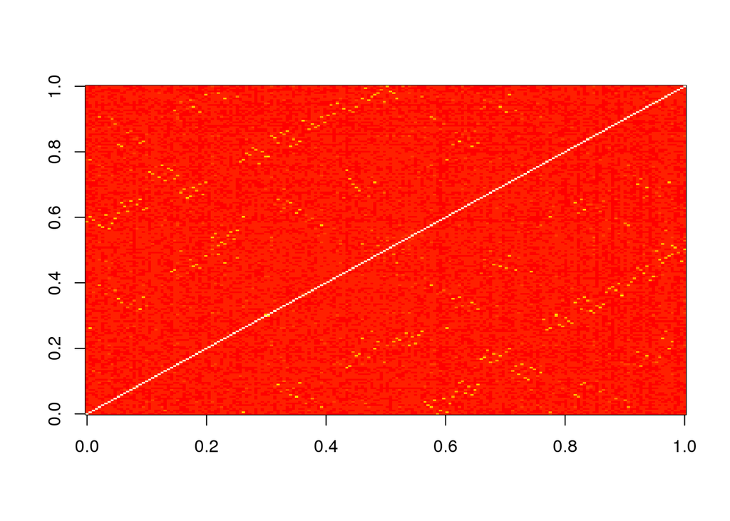

```r
image(K.LOCO.192[[3]])
```

View the distribution of kinship values

```
## stat_bin: binwidth defaulted to range/30. Use 'binwidth = x' to adjust this.
```

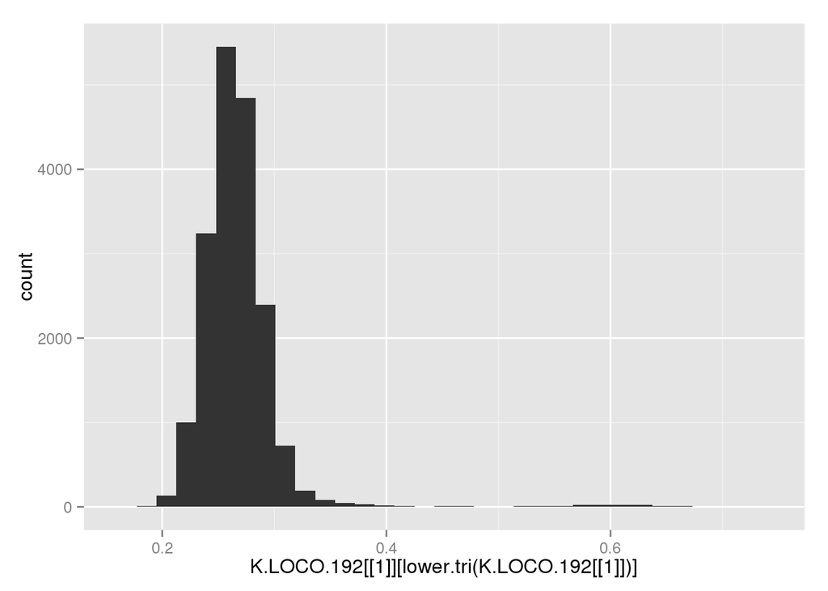

```r
qplot(K.LOCO.192[[1]][lower.tri(K.LOCO.192[[1]])], geom="histogram")
```

Look at a sample of the names.

```r
head(samples.192)
```

```
## [1] "F326" "F327" "F328" "F329" "F330" "F331"
```